# Preprocessing Airbnb Melbourne Dataset

Yoga Pratama & Benjamin Huang

## Required Packages

```r
library(dplyr)
library(tidyr)
library(readr)
library(rvest)
library(stringr)
library(lubridate)
library(forecast)
```

## Executive Summary

For this project, open source data on Airbnb, along with data from a Wikipedia table on Local Government Areas (LGA) were used for the purpose of data pre-processing. The following steps were taken:

- Airbnb data was loaded and subset with the desired variables, while LGA data was scraped via Wikipedia and also subset with the desired variables. These two datasets were then relationally joined to form a new dataset.
- Variables in the new dataset were renamed to better reflect their meanings, and were then converted to more appropriate variable types.
- The dataset was briefly examined to check if it was in a ‘tidy’ format, in which it was hence no further action was taken regarding format.
- New variables were then created from the existing variables and added to the dataset.
- The entire dataset was scanned for NA values and other special values (infinite numbers and ‘Not a Number’ values), which were then removed according to appropriateness.
- Rules were also defined and applied to check for any inconsistencies. For certain rule violations, observations were removed, while for other rule violations, observations were imputed.
- The appropriate variables were scanned for outliers via Tukey’s method based on the distributions of the variables, which were then imputed due to the number of outliers that were found. Other methods were also briefly discussed.
- For the last step, one variable was chosen to be transformed and normalised in order to apply a z-score outlier detection method.

## Data

The main dataset used for this project is the “Melbourne Airbnb Open Data” as hosted on Kaggle by Tyler Xie (https://www.kaggle.com/tylerx/melbourne-airbnb-open-data). The data was gathered from the Inside Airbnb database and compiled by Tyler Xie into a CSV file. There are 96 variables for the Airbnb dataset, however only 12 variables were chosen for the purpose of this project:

- id = Identification number for Airbnb listing.
- host_since = The date when the host of the lisitng signed up to Airbnb as a host.
- street = Street address.
- neighbourhood_cleansed = Local government area.
- property_type = The type of building (eg: House, Apartment, etc.)
- accommodates = The number of guests the accommodation can accommodate.
- bathrooms = The number of bathrooms.
- bedrooms = The number of bedrooms.
- price = Price per night.
- guests_included = The number of guests included in the price per night.
- number_of_reviews = The number of reviews the accommodation has.
- instant_bookable = Whether the accommodation instantly bookable.

Below, the Airbnb dataset is imported and subset according to the varibles chosen above:

```r
airbnb_orig <- read.csv("listings_dec18.csv", stringsAsFactors = F)
airbnb <- airbnb_orig[,c("id","host_since","street","neighbourhood_cleansed","property_type","accommodates",
                         "bathrooms","bedrooms","price","guests_included","number_of_reviews", "instant_bookable")]
head(airbnb)
```

|  | id | host_since | street | neighbourhood_cleansed | property_type | accommodates | bathrooms | bedrooms | price | guests_included | number_of_reviews | instant_bookable |
| --- | --- | --- | --- | --- | --- | --- | --- | --- | --- | --- | --- | --- |
| 1 | 9835 | 2009-08-21 | Bulleen, VIC, Australia | Manningham | House | 2 | 1.0 | 1 | $60.00 | 1 | 4 | f |
| 2 | 10803 | 2009-09-16 | Brunswick East, VIC, Australia | Moreland | Apartment | 2 | 1.0 | 1 | $35.00 | 1 | 108 | t |
| 3 | 12936 | 2009-10-31 | St Kilda, VIC, Australia | Port Phillip | Apartment | 3 | 1.0 | 1 | $159.00 | 2 | 15 | f |
| 4 | 15246 | 2009-12-03 | Thornbury, VIC, Australia | Darebin | House | 1 | 1.5 | 1 | $50.00 | 1 | 29 | f |
| 5 | 16760 | 2009-12-22 | St Kilda East, VIC, Australia | Port Phillip | House | 2 | 1.0 | 1 | $69.00 | 1 | 63 | f |
| 6 | 38271 | 2010-07-12 | Berwick, VIC, Australia | Casey | Apartment | 5 | 1.0 | 3 | $98.00 | 1 | 112 | f |

The second dataset is scraped from a table off the Wikipedia article “Local Government Areas of Victoria” (https://en.wikipedia.org/wiki/Local_government_areas_of_Victoria#Greater_Melbourne). Its variables contain information on land size and population for each LGA. Only 3 variables were chosen out of the 11 variables, which were then renamed:

- LGA = Local government area.
- LGA_Area_km2 = The size of the LGA in kilometres squared.
- LGA_Density = The population density per kilometre squared.

Below, the Wikipedia table is scraped and imported using the ‘rvest’ package, and then subsetted with the chosen variables above. The variables are then renamed, while the LGA observations are edited to remove the strings “City of” or “Shire of” in front of the LGA names. This is so that the LGA variable will match with the ‘neighbourhood_cleansed’ variable in the Airbnb dataset so that the two datasets may be joined in the next step:

```r
LGA_wiki <- read_html("https://en.wikipedia.org/wiki/Local_government_areas_of_Victoria#Greater_Melbourne")
length(html_nodes(LGA_wiki, "table"))
```

```
## [1] 10
```

```r
LGA <- html_table(html_nodes(LGA_wiki, "table") [[1]], fill=T)
head(LGA)
```

|  | Local government area | Council seat | Region | Year est. | Land area | Land area | Land area | Population(2001 census) | Population(2016 census) | Councillors(2012) | Notes | Map |
| --- | --- | --- | --- | --- | --- | --- | --- | --- | --- | --- | --- | --- |
| 1 | Local government area | Council seat | Region | Year est. | km² | Land area | Land area | Population(2001 census) | Population(2016 census) | Councillors(2012) | sq mi | Density(2016) |
| 2 | City of Melbourne | Melbourne | Inner Melbourne | 12 August 1842 (1842-08-12) | 37 | 14 | 3,486 | 60,745[1] | 135,959[2] | 11 | Capital city of Victoria. |  |
| 3 | City of Port Phillip | St Kilda | Inner Melbourne | 22 June 1994 (1994-06-22) | 21 | 8 | 5,101 | 78,227[3] | 100,863[4] | 7 | Amalgamation of the cities of St Kilda, South Melbourne and Port Melbourne. |  |
| 4 | City of Stonnington | Malvern | Inner Melbourne | 22 June 1994 (1994-06-22) | 26 | 10 | 4,152 | 86,090[5] | 103,832[6] | 9 | Amalgamation of the cities of Malvern and Prahran |  |
| 5 | City of Yarra | Richmond | Inner Melbourne | 22 June 1994 (1994-06-22) | 20 | 8 | 4,458 | 67,052[7] | 86,657[8] | 9 | Amalgamation of the cities of Richmond, Collingwood, Fitzroy and Northcote. |  |
| 6 | City of Banyule | Ivanhoe | Metropolitan Melbourne | 15 December 1994 (1994-12-15) | 63 | 24 | 2,004 | 113,696[9] | 121,865[10] | 7 | Amalgamation of the City of Heidelberg and parts of the Shire of Diamond Valley and the Shire of Eltham. |  |

```r
LGA <- LGA[2:32,c(1,5,7)]
colnames(LGA) <- c("LGA","LGA_Area_km2","LGA_Density")
LGA <- LGA %>%
  mutate(LGA = ifelse(str_detect(LGA, "Shire of"), str_replace(LGA, pattern="Shire of ", replacement=""),
               ifelse(str_detect(LGA, "City of"), str_replace(LGA, pattern="City of ", replacement=""), "Error")))
head(LGA)
```

|  | LGA | LGA_Area_km2 | LGA_Density |
| --- | --- | --- | --- |
| 1 | Melbourne | 37 | 3,486 |
| 2 | Port Phillip | 21 | 5,101 |
| 3 | Stonnington | 26 | 4,152 |
| 4 | Yarra | 20 | 4,458 |
| 5 | Banyule | 63 | 2,004 |
| 6 | Bayside | 36 | 2,814 |

The two datasets are joined below, where Airbnb’s ‘neighbourhood_cleansed’ is equal to LGA’s ‘LGA’, to form a dataset with 14 variables:

```r
airbnb_LGA <- left_join(airbnb, LGA, by = c("neighbourhood_cleansed" = "LGA"))
head(airbnb_LGA)
```

|  | id | host_since | street | neighbourhood_cleansed | property_type | accommodates | bathrooms | bedrooms | price | guests_included | number_of_reviews | instant_bookable | LGA_Area_km2 | LGA_Density |
| --- | --- | --- | --- | --- | --- | --- | --- | --- | --- | --- | --- | --- | --- | --- |
| 1 | 9835 | 2009-08-21 | Bulleen, VIC, Australia | Manningham | House | 2 | 1.0 | 1 | $60.00 | 1 | 4 | f | 113 | 1,057 |
| 2 | 10803 | 2009-09-16 | Brunswick East, VIC, Australia | Moreland | Apartment | 2 | 1.0 | 1 | $35.00 | 1 | 108 | t | 51 | 3,270 |
| 3 | 12936 | 2009-10-31 | St Kilda, VIC, Australia | Port Phillip | Apartment | 3 | 1.0 | 1 | $159.00 | 2 | 15 | f | 21 | 5,101 |
| 4 | 15246 | 2009-12-03 | Thornbury, VIC, Australia | Darebin | House | 1 | 1.5 | 1 | $50.00 | 1 | 29 | f | 53 | 2,847 |
| 5 | 16760 | 2009-12-22 | St Kilda East, VIC, Australia | Port Phillip | House | 2 | 1.0 | 1 | $69.00 | 1 | 63 | f | 21 | 5,101 |
| 6 | 38271 | 2010-07-12 | Berwick, VIC, Australia | Casey | Apartment | 5 | 1.0 | 3 | $98.00 | 1 | 112 | f | 410 | 713 |

```r
dim(airbnb_LGA)
```

```
## [1] 22895    14
```

## Understand

```r
str(airbnb_LGA)
```

```
## 'data.frame':    22895 obs. of  14 variables:
##  $ id                    : int  9835 10803 12936 15246 16760 38271 41836 43414 43429 44082 ...
##  $ host_since            : chr  "2009-08-21" "2009-09-16" "2009-10-31" "2009-12-03" ...
##  $ street                : chr  "Bulleen, VIC, Australia" "Brunswick East, VIC, Australia" "St Kilda, VIC, Australia" "Thornbury, VIC, Australia" ...
##  $ neighbourhood_cleansed: chr  "Manningham" "Moreland" "Port Phillip" "Darebin" ...
##  $ property_type         : chr  "House" "Apartment" "Apartment" "House" ...
##  $ accommodates          : int  2 2 3 1 2 5 2 2 2 2 ...
##  $ bathrooms             : num  1 1 1 1.5 1 1 1 1 1 1 ...
##  $ bedrooms              : int  1 1 1 1 1 3 1 1 1 1 ...
##  $ price                 : chr  "$60.00" "$35.00" "$159.00" "$50.00" ...
##  $ guests_included       : int  1 1 2 1 1 1 2 1 1 1 ...
##  $ number_of_reviews     : int  4 108 15 29 63 112 159 3 168 28 ...
##  $ instant_bookable      : chr  "f" "t" "f" "f" ...
##  $ LGA_Area_km2          : chr  "113" "51" "21" "53" ...
##  $ LGA_Density           : chr  "1,057" "3,270" "5,101" "2,847" ...
```

As seen above, the imported data structure is a data frame, however the majority of the variables are not the correct variable type. Before performing data type conversions, some of the variables will be renamed to make more sense:

```r
colnames(airbnb_LGA)[4] <- "LGA"
colnames(airbnb_LGA)[3] <- "location"
head(airbnb_LGA)
```

|  | id | host_since | location | LGA | property_type | accommodates | bathrooms | bedrooms | price | guests_included | number_of_reviews | instant_bookable | LGA_Area_km2 | LGA_Density |
| --- | --- | --- | --- | --- | --- | --- | --- | --- | --- | --- | --- | --- | --- | --- |
| 1 | 9835 | 2009-08-21 | Bulleen, VIC, Australia | Manningham | House | 2 | 1.0 | 1 | $60.00 | 1 | 4 | f | 113 | 1,057 |
| 2 | 10803 | 2009-09-16 | Brunswick East, VIC, Australia | Moreland | Apartment | 2 | 1.0 | 1 | $35.00 | 1 | 108 | t | 51 | 3,270 |
| 3 | 12936 | 2009-10-31 | St Kilda, VIC, Australia | Port Phillip | Apartment | 3 | 1.0 | 1 | $159.00 | 2 | 15 | f | 21 | 5,101 |
| 4 | 15246 | 2009-12-03 | Thornbury, VIC, Australia | Darebin | House | 1 | 1.5 | 1 | $50.00 | 1 | 29 | f | 53 | 2,847 |
| 5 | 16760 | 2009-12-22 | St Kilda East, VIC, Australia | Port Phillip | House | 2 | 1.0 | 1 | $69.00 | 1 | 63 | f | 21 | 5,101 |
| 6 | 38271 | 2010-07-12 | Berwick, VIC, Australia | Casey | Apartment | 5 | 1.0 | 3 | $98.00 | 1 | 112 | f | 410 | 713 |

Below, the following conversions take place:

- id: Numeric to Factor
- host_since: Character to Date
- property_type: Character to Factor
- instant_bookable: Character to Factor
- LGA: Character to Factor
- accommodates: Character to Ordinal Factor
- bathrooms: Character to Ordinal Factor
- bedrooms: Character to Ordinal Factor
- guests_included: Character to Ordinal Factor
- price: Character to Numeric
- LGA_Area_km2: Character to Numeric
- LGA_Density: Character to Numeric

For the last 3 variables, readr’s parse_number function is used to remove dollar signs and commas in order to convert the characters into numerics:

```r
airbnb_LGA$id <- as.factor(airbnb_LGA$id)
airbnb_LGA$host_since <- ymd(airbnb_LGA$host_since)
airbnb_LGA$property_type <- factor(airbnb_LGA$property_type)
airbnb_LGA$instant_bookable <- factor(airbnb_LGA$instant_bookable)
airbnb_LGA$LGA <- factor(airbnb_LGA$LGA)

unique(airbnb_LGA$accommodates)
```

```
##  [1]  2  3  1  5  4  7 10  6  8 16  9 13 11 12 14 15
```

```r
airbnb_LGA$accommodates <- factor(airbnb_LGA$accommodates,
                                  levels = c("1","2","3","4","5","6","7","8","9","10","11","12","13","14","15"),
                                  ordered = T)
levels(airbnb_LGA$accommodates)
```

```
##  [1] "1"  "2"  "3"  "4"  "5"  "6"  "7"  "8"  "9"  "10" "11" "12" "13" "14"
## [15] "15"
```

```r
unique(airbnb_LGA$bathrooms)
```

```
##  [1]  1.0  1.5  2.5  2.0   NA  3.0  6.0  0.5  0.0  5.0  8.0  4.0  3.5  4.5
## [15]  7.0 14.0  9.0  7.5  5.5  6.5 10.0
```

```r
airbnb_LGA$bathrooms <- factor(airbnb_LGA$bathrooms,
                                  levels = c("0","0.5","1","1.5","2","2.5","3","3.5","4","4.5","5","5.5",
                                             "6","6.5","7","7.5","8","9","10","14"),
                                  ordered = T)
levels(airbnb_LGA$bathrooms)
```

```
##  [1] "0"   "0.5" "1"   "1.5" "2"   "2.5" "3"   "3.5" "4"   "4.5" "5"
## [12] "5.5" "6"   "6.5" "7"   "7.5" "8"   "9"   "10"  "14"
```

```r
unique(airbnb_LGA$bedrooms)
```

```
##  [1]  1  3  2  4  5 10  0  6  7  9 NA 16  8 11
```

```r
airbnb_LGA$bedrooms <- factor(airbnb_LGA$bedrooms,
                               levels = c("0","1","2","3","4","5","6","7","8","9","10","11"),
                               ordered = T)
levels(airbnb_LGA$bedrooms)
```

```
##  [1] "0"  "1"  "2"  "3"  "4"  "5"  "6"  "7"  "8"  "9"  "10" "11"
```

```r
unique(airbnb_LGA$guests_included)
```

```
##  [1]  1  2  3  6  4  8 12  5  9  7 16 10 11 15 14
```

```r
airbnb_LGA$guests_included <- factor(airbnb_LGA$guests_included,
                              levels = c("1","2","3","4","5","6","7","8","9","10","11","12","14","15","16"),
                              ordered = T)
levels(airbnb_LGA$guests_included)
```

```
##  [1] "1"  "2"  "3"  "4"  "5"  "6"  "7"  "8"  "9"  "10" "11" "12" "14" "15"
## [15] "16"
```

```r
airbnb_LGA$price <- parse_number(airbnb_LGA$price)
airbnb_LGA$LGA_Area_km2 <- parse_number(airbnb_LGA$LGA_Area_km2)
airbnb_LGA$LGA_Density <- parse_number(airbnb_LGA$LGA_Density)
```

The following is the dataset after the variable type conversions:

```r
str(airbnb_LGA)
```

```
## 'data.frame':    22895 obs. of  14 variables:
##  $ id               : Factor w/ 22895 levels "9835","10803",..: 1 2 3 4 5 6 7 8 9 10 ...
##  $ host_since       : Date, format: "2009-08-21" "2009-09-16" ...
##  $ location         : chr  "Bulleen, VIC, Australia" "Brunswick East, VIC, Australia" "St Kilda, VIC, Australia" "Thornbury, VIC, Australia" ...
##  $ LGA              : Factor w/ 30 levels "Banyule","Bayside",..: 15 22 24 7 24 6 7 18 20 8 ...
##  $ property_type    : Factor w/ 35 levels "Aparthotel","Apartment",..: 22 2 2 22 22 2 22 2 2 22 ...
##  $ accommodates     : Ord.factor w/ 15 levels "1"<"2"<"3"<"4"<..: 2 2 3 1 2 5 2 2 2 2 ...
##  $ bathrooms        : Ord.factor w/ 20 levels "0"<"0.5"<"1"<..: 3 3 3 4 3 3 3 3 3 3 ...
##  $ bedrooms         : Ord.factor w/ 12 levels "0"<"1"<"2"<"3"<..: 2 2 2 2 2 4 2 2 2 2 ...
##  $ price            : num  60 35 159 50 69 98 50 100 98 60 ...
##  $ guests_included  : Ord.factor w/ 15 levels "1"<"2"<"3"<"4"<..: 1 1 2 1 1 1 2 1 1 1 ...
##  $ number_of_reviews: int  4 108 15 29 63 112 159 3 168 28 ...
##  $ instant_bookable : Factor w/ 2 levels "f","t": 1 2 1 1 1 1 1 1 2 1 ...
##  $ LGA_Area_km2     : num  113 51 21 53 21 410 53 37 82 131 ...
##  $ LGA_Density      : num  1057 3270 5101 2847 5101 ...
```

## Tidy & Manipulate Data I

The dataset is in a tidy format since the following apply:

- Each variable has its own column.
- Each observation has its own row.
- Each value has its own cell.

## Tidy & Manipulate Data II

Below, two new variables are created via the mutate function (from dplyr). The variable ‘price_per_guest’ is created by dividing the price (‘price’) by the number of guests included (‘guest_included’). As ‘guests_included’ was converted to a factor earlier, it is temporarily coerced into a numeric in order for the arithmetic to work. The variable ‘LGA_population’ is created by multiplying the LGA area (LGA_Area_km2) with the LGA population density (LGA_Density):

```r
airbnb_LGA <- airbnb_LGA %>%
  mutate(price_per_guest = round(price/as.numeric(guests_included), 2),
         LGA_population = LGA_Area_km2*LGA_Density)
head(airbnb_LGA)
```

|  | id | host_since | location | LGA | property_type | accommodates | bathrooms | bedrooms | price | guests_included | number_of_reviews | instant_bookable | LGA_Area_km2 | LGA_Density | price_per_guest | LGA_population |
| --- | --- | --- | --- | --- | --- | --- | --- | --- | --- | --- | --- | --- | --- | --- | --- | --- |
| 1 | 9835 | 2009-08-21 | Bulleen, VIC, Australia | Manningham | House | 2 | 1 | 1 | 60 | 1 | 4 | f | 113 | 1057 | 60.0 | 119441 |
| 2 | 10803 | 2009-09-16 | Brunswick East, VIC, Australia | Moreland | Apartment | 2 | 1 | 1 | 35 | 1 | 108 | t | 51 | 3270 | 35.0 | 166770 |
| 3 | 12936 | 2009-10-31 | St Kilda, VIC, Australia | Port Phillip | Apartment | 3 | 1 | 1 | 159 | 2 | 15 | f | 21 | 5101 | 79.5 | 107121 |
| 4 | 15246 | 2009-12-03 | Thornbury, VIC, Australia | Darebin | House | 1 | 1.5 | 1 | 50 | 1 | 29 | f | 53 | 2847 | 50.0 | 150891 |
| 5 | 16760 | 2009-12-22 | St Kilda East, VIC, Australia | Port Phillip | House | 2 | 1 | 1 | 69 | 1 | 63 | f | 21 | 5101 | 69.0 | 107121 |
| 6 | 38271 | 2010-07-12 | Berwick, VIC, Australia | Casey | Apartment | 5 | 1 | 3 | 98 | 1 | 112 | f | 410 | 713 | 98.0 | 292330 |

```r
airbnb_LGA <- airbnb_LGA %>% separate(location, into = c("Suburb", "State", "Country"), sep = ",")
head(airbnb_LGA)
```

|  | id | host_since | Suburb | State | Country | LGA | property_type | accommodates | bathrooms | bedrooms | price | guests_included | number_of_reviews | instant_bookable | LGA_Area_km2 | LGA_Density | price_per_guest | LGA_population |
| --- | --- | --- | --- | --- | --- | --- | --- | --- | --- | --- | --- | --- | --- | --- | --- | --- | --- | --- |
| 1 | 9835 | 2009-08-21 | Bulleen | VIC | Australia | Manningham | House | 2 | 1 | 1 | 60 | 1 | 4 | f | 113 | 1057 | 60.0 | 119441 |
| 2 | 10803 | 2009-09-16 | Brunswick East | VIC | Australia | Moreland | Apartment | 2 | 1 | 1 | 35 | 1 | 108 | t | 51 | 3270 | 35.0 | 166770 |
| 3 | 12936 | 2009-10-31 | St Kilda | VIC | Australia | Port Phillip | Apartment | 3 | 1 | 1 | 159 | 2 | 15 | f | 21 | 5101 | 79.5 | 107121 |
| 4 | 15246 | 2009-12-03 | Thornbury | VIC | Australia | Darebin | House | 1 | 1.5 | 1 | 50 | 1 | 29 | f | 53 | 2847 | 50.0 | 150891 |
| 5 | 16760 | 2009-12-22 | St Kilda East | VIC | Australia | Port Phillip | House | 2 | 1 | 1 | 69 | 1 | 63 | f | 21 | 5101 | 69.0 | 107121 |
| 6 | 38271 | 2010-07-12 | Berwick | VIC | Australia | Casey | Apartment | 5 | 1 | 3 | 98 | 1 | 112 | f | 410 | 713 | 98.0 | 292330 |

## Scan I

Below, the sapply function is used to scan all variables in the dataset for NA values:

```r
sapply(airbnb_LGA, function(x) sum(is.na(x)))
```

```
##                id        host_since            Suburb             State
##                 0                 3                 0                 0
##           Country               LGA     property_type      accommodates
##                61                 0                 0                81
##         bathrooms          bedrooms             price   guests_included
##                17                 7                 0                 0
## number_of_reviews  instant_bookable      LGA_Area_km2       LGA_Density
##                 0                 0                 0                 0
##   price_per_guest    LGA_population
##                 0                 0
```

```r
sum(is.na(airbnb_LGA))
```

```
## [1] 169
```

```r
airbnb_LGA <- na.omit(airbnb_LGA)

sapply(airbnb_LGA, function(x) sum(is.na(x)))
```

```
##                id        host_since            Suburb             State
##                 0                 0                 0                 0
##           Country               LGA     property_type      accommodates
##                 0                 0                 0                 0
##         bathrooms          bedrooms             price   guests_included
##                 0                 0                 0                 0
## number_of_reviews  instant_bookable      LGA_Area_km2       LGA_Density
##                 0                 0                 0                 0
##   price_per_guest    LGA_population
##                 0                 0
```

Below is a function to scan all numerical variables for special values such as infinite numbers or NaNs, which is applied to the entire dataset. The results indicate that there are no special values in this dataset:

```r
special <- function(x){if (is.numeric(x)) sum(is.infinite(x) | is.nan(x))}
sapply(airbnb_LGA, special)
```

```
## $id
## NULL
##
## $host_since
## NULL
##
## $Suburb
## NULL
##
## $State
## NULL
##
## $Country
## NULL
##
## $LGA
## NULL
##
## $property_type
## NULL
##
## $accommodates
## NULL
##
## $bathrooms
## NULL
##
## $bedrooms
## NULL
##
## $price
## [1] 0
##
## $guests_included
## NULL
##
## $number_of_reviews
## [1] 0
##
## $instant_bookable
## NULL
##
## $LGA_Area_km2
## [1] 0
##
## $LGA_Density
## [1] 0
##
## $price_per_guest
## [1] 0
##
## $LGA_population
## [1] 0
```

Check inconsistency from separated variable, “Suburb”, “State”, and “Country”

```r
unique (airbnb_LGA$Suburb)
```

```
##   [1] "Bulleen"                      "Brunswick East"
##   [3] "St Kilda"                     "Thornbury"
##   [5] "St Kilda East"                "Berwick"
##   [7] "Reservoir"                    "East Melbourne"
##   [9] "Oakleigh East"                "Frankston"
##  [11] "Richmond"                     "Melbourne"
##  [13] "Brighton East"                "Kew"
##  [15] "Fitzroy"                      "Hampton"
##  [17] "Clifton Hill"                 "Mordialloc"
##  [19] "Northcote"                    "Port Melbourne"
##  [21] "South Melbourne"              "Prahran"
##  [23] "Saint Kilda East"             "Parkdale"
##  [25] "Ringwood East"                "Parkville"
##  [27] "Yarraville"                   "Belgrave"
##  [29] "Chum Creek"                   "Ivanhoe"
```

[output cut: 253 more lines]

change all observation to lower case using stringr function

```r
airbnb_LGA$Suburb <- str_to_lower(airbnb_LGA$Suburb)
```

```r
unique (airbnb_LGA$State)
```

```
##  [1] " VIC"                     " Vic"
##  [3] " vic"                     " Melbourne"
##  [5] " ç»´å¤šå\210©äºšå·ž"         " Yarra Valley"
##  [7] " Melbourne."              "10minutes to Warburton"
##  [9] " Yarra Glen"              " VICTORIA"
## [11] " Victoria"                " ç»´å¤šå\210©äºš"
## [13] " St. Kilda "              " St. Kilda"
## [15] " ç¶å¤šå\210©äºž VIC"        " victoria"
## [17] " Melbourne VIC 3000"      " Wheelers Hill VIC 3150"
## [19] " South Yarra VIC 3141"    " NSW"
## [21] " Doncaster VIC 3108"      " Somerton VIC 3062"
## [23] " Brunswick VIC 3056"      " Wantirna South VIC 3152"
## [25] " Melbourne VIC 3004"      " Australia"
## [27] " VI"                      " VICtoria"
## [29] " VIC 3008"                " Victory"
## [31] " QLD"                     " Mel"
```

```r
unique (airbnb_LGA$Country)
```

```
## [1] " Australia"   " VIC"         " Healesville" " AU"
## [5] " Victoria"
```

The actual airbnb location is in Victoria and Australia, so other than that will be changed to “VIC” and “AU”

```r
airbnb_LGA$State <- replace(airbnb_LGA$State, airbnb_LGA$State != "VIC", "VIC")

airbnb_LGA$Country <- replace(airbnb_LGA$Country, airbnb_LGA$Country != "AU", "AU")
```

Using the editrules package, the following code sets some basic rules to scan for inconsistencies. The rules defined below are to make sure that no numerical value is a negative number. For the price variable however, the rule makes sure that no value is below 5 as for the purpose of this project, any Airbnb accommodation for less than $5 per night is considered a mistake or is not a legitimate listing. There are 22 violations under the rule number 1 (price >= 5), those of which can be seen below:

```r
library(editrules)
rules <- editset(c("price >= 5",
                   "price_per_guest >= 0",
                   "number_of_reviews >= 0",
                   "LGA_Area_km2 >= 0",
                   "LGA_Density >= 0",
                   "LGA_population >= 0"))
rules
```

```
##
## Edit set:
## num1 : 5 <= price
## num2 : 0 <= price_per_guest
## num3 : 0 <= number_of_reviews
## num4 : 0 <= LGA_Area_km2
## num5 : 0 <= LGA_Density
## num6 : 0 <= LGA_population
```

```r
summary(violatedEdits(rules,airbnb_LGA))
```

```
## Edit violations, 22729 observations, 0 completely missing (0%):
##
##  editname freq  rel
##      num1   22 0.1%
##
## Edit violations per record:
##
##  errors  freq   rel
##       0 22707 99.9%
##       1    22  0.1%
```

```r
which(violatedEdits(rules,airbnb_LGA))
```

```
##  [1]  9820 10054 10903 10906 10907 10908 10909 10911 10912 10913 10914
## [12] 11457 11497 11608 11789 12298 12302 12428 12493 12607 14480 17703
```

The observations with violated rules are removed, resulting in zero violated rules:

```r
airbnb_LGA <- airbnb_LGA[-(which(violatedEdits(rules,airbnb_LGA))),]
summary(violatedEdits(rules,airbnb_LGA))
```

```
## No violations detected, 0 checks evaluated to NA
```

Another inconsistency within the dataset is that some values of the guests_included variable are larger than the accommodates variable, which is impossible as ‘accommodates’ is the maximum number of guests allowed to stay in the accommodation. Below, it is shown that 108 observations have guests_included being larger than accommodates.

```r
summary(as.numeric(airbnb_LGA$guests_included) > as.numeric(airbnb_LGA$accommodates))
```

```
##    Mode   FALSE    TRUE
## logical   22599     108
```

```r
which(as.numeric(airbnb_LGA$guests_included) > as.numeric(airbnb_LGA$accommodates))
```

```
##   [1]    80   227   323   364   592   751   831  1608  1882  1904  2271
##  [12]  2273  2725  2898  3064  3355  3396  3636  3751  3838  4083  4220
##  [23]  4294  4640  4770  4927  5702  6251  6402  6405  6424  6850  7003
##  [34]  7316  7910  8138  8441  8549  8705  9326  9357 10269 10283 10647
##  [45] 10677 10722 10831 10920 10970 11393 11460 11598 11699 11934 12033
##  [56] 12035 12079 12083 12112 12241 12443 12744 13153 13294 13349 13385
##  [67] 13527 13549 13778 14027 14484 15131 15348 15583 16030 16249 16350
##  [78] 16650 16778 17620 17839 17883 18019 18095 18156 18281 18394 18427
##  [89] 18428 19441 19478 19934 20221 20413 20423 20782 20806 20821 21006
## [100] 21094 21494 21633 21664 21680 21826 21828 21834 22542
```

To deal with this, an ifelse statement is used to determine the observations with this inconsistency, which are then imputed with the the value from the accommodates variable:

```r
airbnb_LGA <- airbnb_LGA %>%
  mutate(guests_included = ifelse(as.numeric(guests_included) <= as.numeric(accommodates), guests_included, accommodates))

summary(as.numeric(airbnb_LGA$guests_included) > as.numeric(airbnb_LGA$accommodates))
```

```
##    Mode   FALSE
## logical   22707
```

## Scan II

Before scanning for outliers, an upper threshold will be applied to the price variable in order to remove listings with obvious pricing errors. A search on Airbnb listings in Victoria show that the most luxurious mansions list for no more than $3,500 per night, while a wedding reception accommodation is listed for around $5,000. Listings higher than $5,000 per night are usually small dwellings, which are the result of pricing errors or that they’re not legitimate listings. The following shows that the dataset contains prices that go up into the $12,000 range. Any listing with prices above $5,000 per night is removed:

```r
max(airbnb_LGA$price)
```

```
## [1] 12624
```

```r
which(airbnb_LGA$price > 5000)
```

```
## [1]  5596  7823  8070 19392
```

```r
airbnb_LGA <- airbnb_LGA[-(which(airbnb_LGA$price > 5000)),]
max(airbnb_LGA$price)
```

```
## [1] 4445
```

In terms of scanning the numerical variables for outliers, ‘LGA_Area_km2’, ‘LGA_Density’, and ‘LGA_population’ will not be scanned since these values are tied to the factor variable ‘LGA’ which contain 30 factors, hence only giving 30 unique values for each of these variables. Any outliers resulting from these variables will not be removed or imputed as they simply demonstrate that some LGAs may have significantly lower or higher populations relative to each other. The numerical variables that will be scanned are ‘price’, ‘price_per_guest’, and ‘number_of_reviews’.

Below, it is shown that all 3 of the variables are right-skewed due to the fact that Airbnb prices and the number of reviews cannot be negative, but can be extremely large. Because of this, Tukey’s method (boxplot) will be used to detect outliers as it does not require the assumption of normality. It is shown that the number of outliers for each variable is quite large, with all of them making up more than five percent of the total observations. This means that imputation will be used to deal with these outliers as opposed to removal. It is also important to note that the following outliers probably do not represent errors. Under normal circumstances, these outliers will be left alone as they represent real and correct values that describe the distribution of Airbnb prices and number of reviews, however for the purpose of demonstration, they will be dealt with.

**Price:**

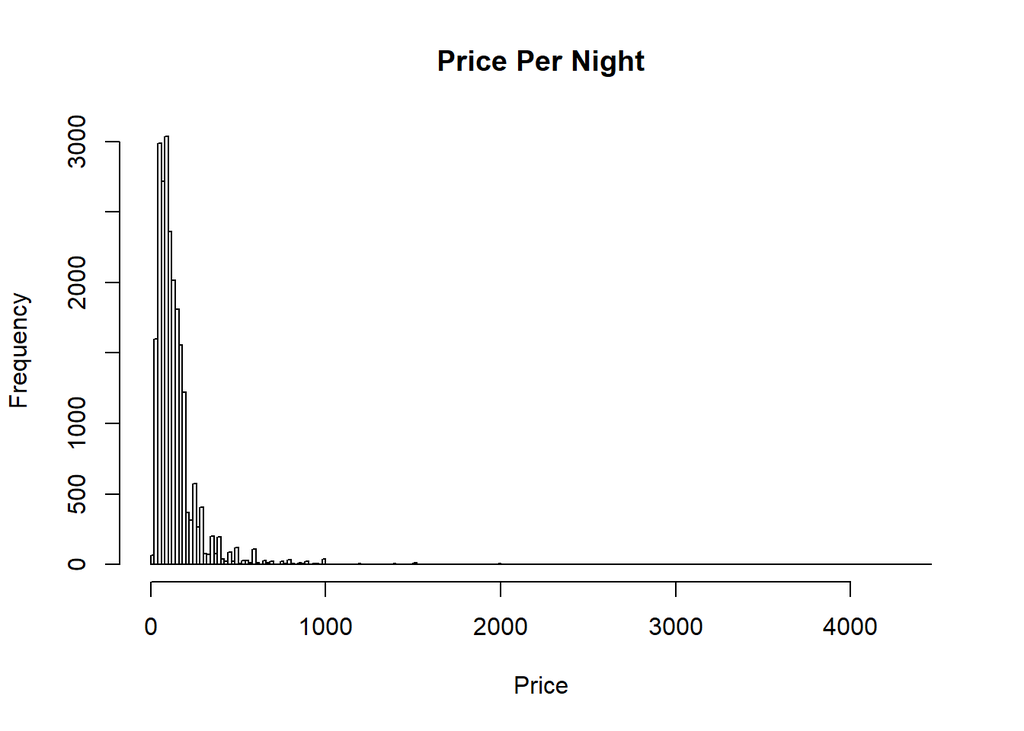

```r
hist(airbnb_LGA$price, breaks = 200, main="Price Per Night", xlab="Price")
```

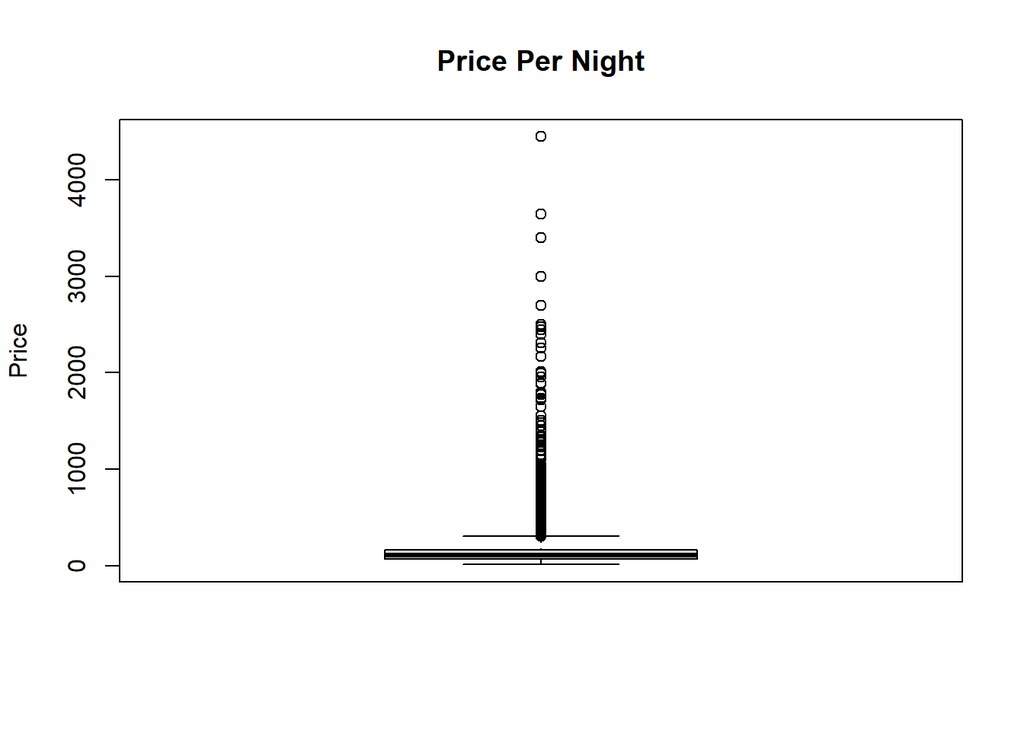

```r
price_box <- airbnb_LGA$price %>%
  boxplot(main="Price Per Night", ylab="Price", col = "lightgrey")
```

```r
summary(airbnb_LGA$price)
```

```
##    Min. 1st Qu.  Median    Mean 3rd Qu.    Max.
##      12      71     109     145     165    4445
```

```r
length(price_box$out)
```

```
## [1] 1397
```

```r
length(price_box$out)/nrow(airbnb_LGA)
```

```
## [1] 0.06153372
```

**Price Per Guest:**

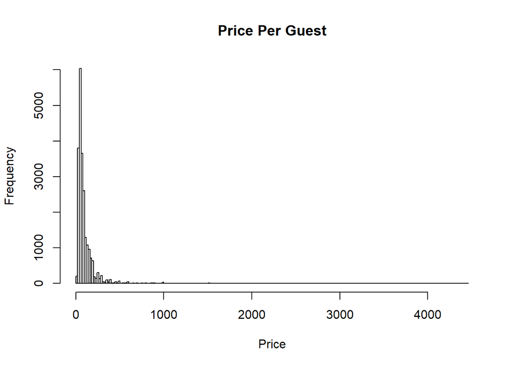

```r
hist(airbnb_LGA$price_per_guest, breaks = 200, main="Price Per Guest", xlab="Price")
```

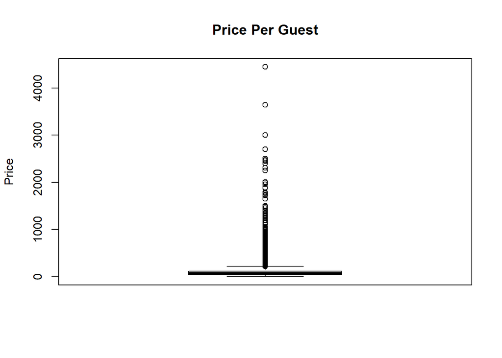

```r
price_per_guest_box <- airbnb_LGA$price_per_guest %>%
  boxplot(main="Price Per Guest", ylab="Price", col = "lightgrey")
```

```r
summary(airbnb_LGA$price_per_guest)
```

```
##    Min. 1st Qu.  Median    Mean 3rd Qu.    Max.
##    2.86   46.50   68.00  102.86  116.00 4445.00
```

```r
length(price_per_guest_box$out)
```

```
## [1] 1557
```

```r
length(price_per_guest_box$out)/nrow(airbnb_LGA)
```

```
## [1] 0.06858124
```

**Number of Reviews:**

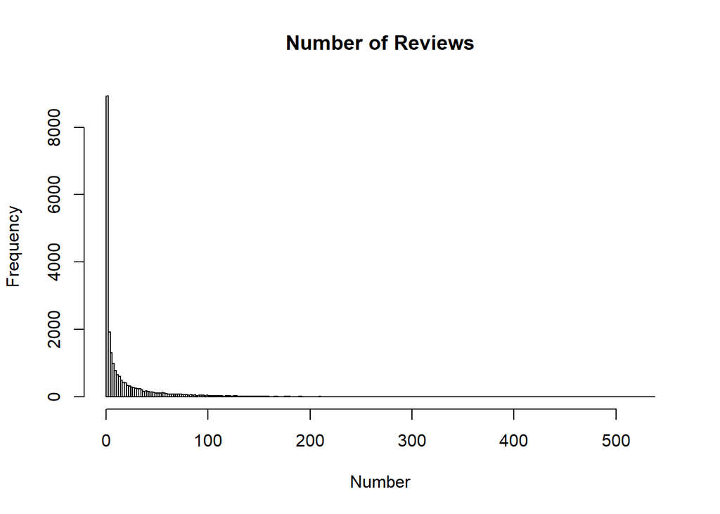

```r
hist(airbnb_LGA$number_of_reviews, breaks = 200, main="Number of Reviews", xlab="Number")
```

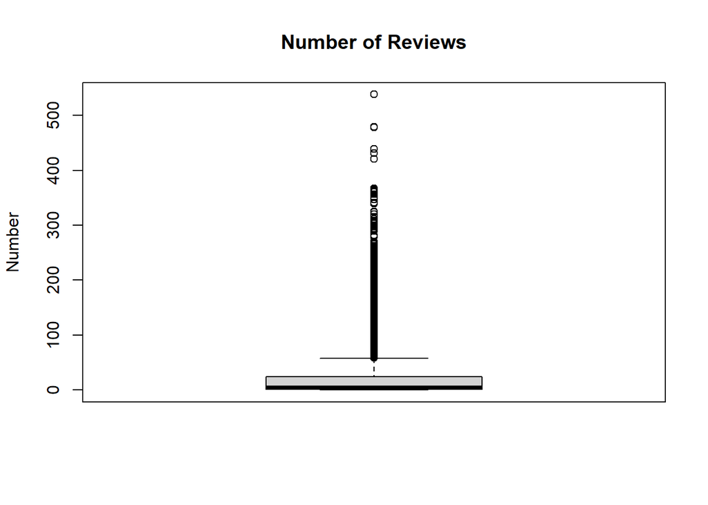

```r
number_of_reviews_box <- airbnb_LGA$number_of_reviews %>%
  boxplot(main="Number of Reviews", ylab="Number", col = "lightgrey")
```

```r
summary(airbnb_LGA$number_of_reviews)
```

```
##    Min. 1st Qu.  Median    Mean 3rd Qu.    Max.
##    0.00    1.00    5.00   21.34   24.00  538.00
```

```r
length(number_of_reviews_box$out)
```

```
## [1] 2480
```

```r
length(number_of_reviews_box$out)/nrow(airbnb_LGA)
```

```
## [1] 0.1092367
```

For this dataset, imputation is done via imputing the outliers with the median since the distributions are extremely skewed. Winsorising was considered, however it would’ve resulted in a large spike in the nearest neighbour of the distribution given the large number of outliers. The median method used also resulted in a large spike in the median of the distribution, so neither solution is ideal (later in the “Transform” section another technique will be explored: the variable ‘price_duplicate’ is created in the code below for later transformation). For each variable, the following code replaces the outliers found above (that were found using the boxplot function) with the median of its variable:

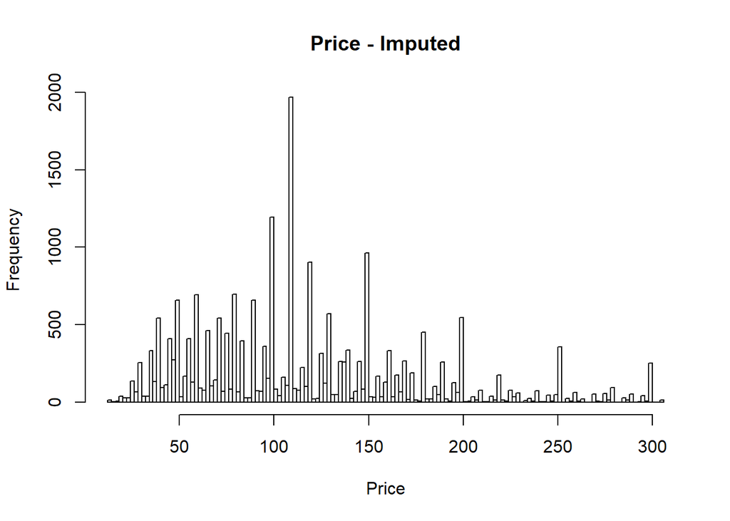

```r
airbnb_LGA <- airbnb_LGA %>%
  mutate(price_duplicate = price)

airbnb_LGA$price[which(airbnb_LGA$price < price_box$stats[1] | airbnb_LGA$price > price_box$stats[5])] <-
  median(airbnb_LGA$price)
hist(airbnb_LGA$price, breaks = 200, main="Price - Imputed", xlab="Price")
```

```r
summary(airbnb_LGA$price)
```

```
##    Min. 1st Qu.  Median    Mean 3rd Qu.    Max.
##    12.0    71.0   109.0   116.7   150.0   306.0
```

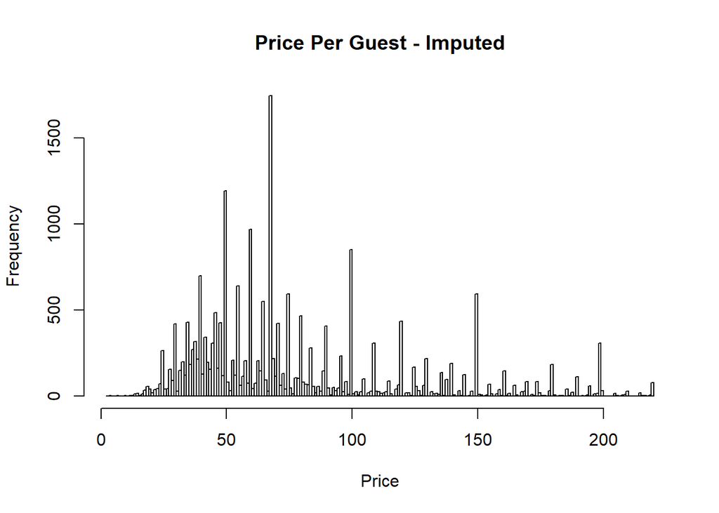

```r
airbnb_LGA$price_per_guest[which(airbnb_LGA$price_per_guest < price_per_guest_box$stats[1] | airbnb_LGA$price_per_guest > price_per_guest_box$stats[5])] <-
  median(airbnb_LGA$price_per_guest)
hist(airbnb_LGA$price_per_guest, breaks = 200, main="Price Per Guest - Imputed", xlab="Price")
```

```r
summary(airbnb_LGA$price_per_guest)
```

```
##    Min. 1st Qu.  Median    Mean 3rd Qu.    Max.
##    2.86   46.50   68.00   77.64   99.50  220.00
```

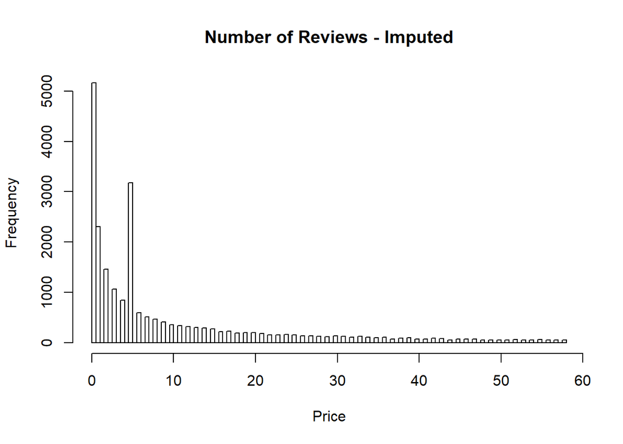

```r
airbnb_LGA$number_of_reviews[which(airbnb_LGA$number_of_reviews < number_of_reviews_box$stats[1] | airbnb_LGA$number_of_reviews > number_of_reviews_box$stats[5])] <-
  median(airbnb_LGA$number_of_reviews)
hist(airbnb_LGA$number_of_reviews, breaks = 200, main="Number of Reviews - Imputed", xlab="Price")
```

```r
summary(airbnb_LGA$number_of_reviews)
```

```
##    Min. 1st Qu.  Median    Mean 3rd Qu.    Max.
##   0.000   1.000   5.000   9.563  12.000  58.000
```

## Transform

In this section, the ‘price_duplicate’ variable is transformed and normalised in order to perform a z-score outlier detection. The following uses the ‘forecast’ package in order to perform a BoxCox transformation. Comparing the tranformed distribution with original distribution, the transformed distribution is much more normal:

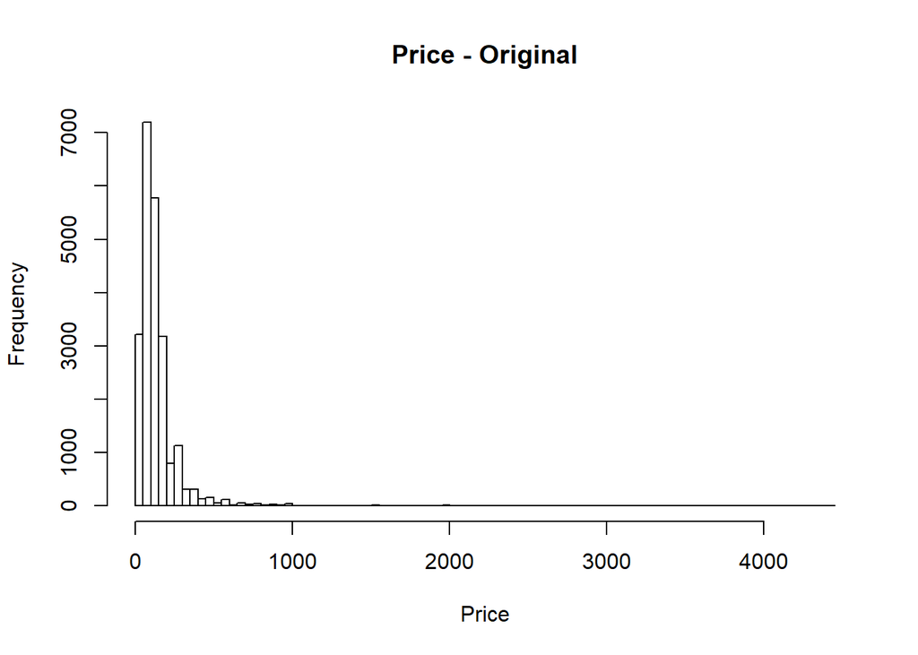

```r
hist(airbnb_LGA$price_duplicate, breaks = 100, main="Price - Original", xlab="Price")
```

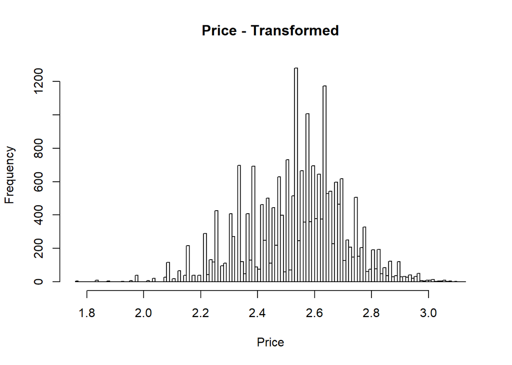

```r
price_boxcox <- BoxCox(airbnb_LGA$price_duplicate,lambda = "auto")
hist(price_boxcox, breaks = 100, main="Price - Transformed", xlab="Price")
```

```r
z_scores <- scale(price_boxcox, center = T, scale = T)
summary(z_scores)
```

```
##        V1
##  Min.   :-4.49789
##  1st Qu.:-0.60448
##  Median : 0.06852
##  Mean   : 0.00000
##  3rd Qu.: 0.64397
##  Max.   : 3.40560
```

```r
length(which(abs(z_scores) > 3))
```

```
## [1] 89
```